# DE analysis

Differential expression analysis aims at distinguish the cluster of genes that are over- or under- represented in each sample. Comparing case and control samples aims at identifying which are the genes correlated to the disease.

### 0. importing data

Import the dataframe and filter unuseful information

```r
data <- read.table("reads_gene_counts.txt",
                   header = TRUE,
                   sep = "\t")
colnames(data)
```

```
##  [1] "Geneid"     "Chr"        "Start"      "End"        "Strand"
##  [6] "Length"     "SRR7821918" "SRR7821919" "SRR7821920" "SRR7821921"
## [11] "SRR7821922" "SRR7821923" "SRR7821924" "SRR7821925" "SRR7821927"
## [16] "SRR7821937" "SRR7821938" "SRR7821939" "SRR7821940" "SRR7821941"
## [21] "SRR7821942"
```

```r
dim(data)
```

```
## [1] 78334    21
```

results in a table with 78334 obs for 21 variables (15 of which are our samples). Then, filter for the columns corresponding to the samples and ignore the rest of the information. Specifically, remove the columns containing Chr, Start, End, Strand and Length.

```r
data <- data[,-2:-6]
colnames(data)
```

```
##  [1] "Geneid"     "SRR7821918" "SRR7821919" "SRR7821920" "SRR7821921"
##  [6] "SRR7821922" "SRR7821923" "SRR7821924" "SRR7821925" "SRR7821927"
## [11] "SRR7821937" "SRR7821938" "SRR7821939" "SRR7821940" "SRR7821941"
## [16] "SRR7821942"
```

Create a matrix ready to feed into DESeq2. It has to be “numeric”.

```r
rownames(data) <- data[,1]   # set first column as row names
data <- data[ , -1]          # remove the first column
```

## 5. Exploratory data analysis (DESeq2)

Install DESeq2

```
if (!require("BiocManager", quietly = TRUE))
    install.packages("BiocManager")

BiocManager::install("DESeq2")
```

Get the sample information into a table containing the sample name and to which group it belongs.

```r
sample_info <- read.delim(
  "sample_info.txt",
  header = TRUE,
  sep = " ",
  stringsAsFactors = FALSE,
  check.names = FALSE
)
```

Now give the data to DEseq2 so that it can create a dds (DESeq Data Set that is created from the data matrix).

```r
dds <- DESeq2::DESeqDataSetFromMatrix(countData = data,
                               colData = sample_info,
                               design= ~ Group)  # UNUSEFUL do not change df to matrix and then df again
```

Now remove the dependence of the variance on the mean by running `DESeq2::vst()` on dds. For visualization, we typically do not want to consider the experimental groups so set `blind = TRUE`.

plot the PCA to check whether it is all right with the data and it is possible to distinguish in the 4 clusters where they belong to.

```
## using ntop=500 top features by variance
```

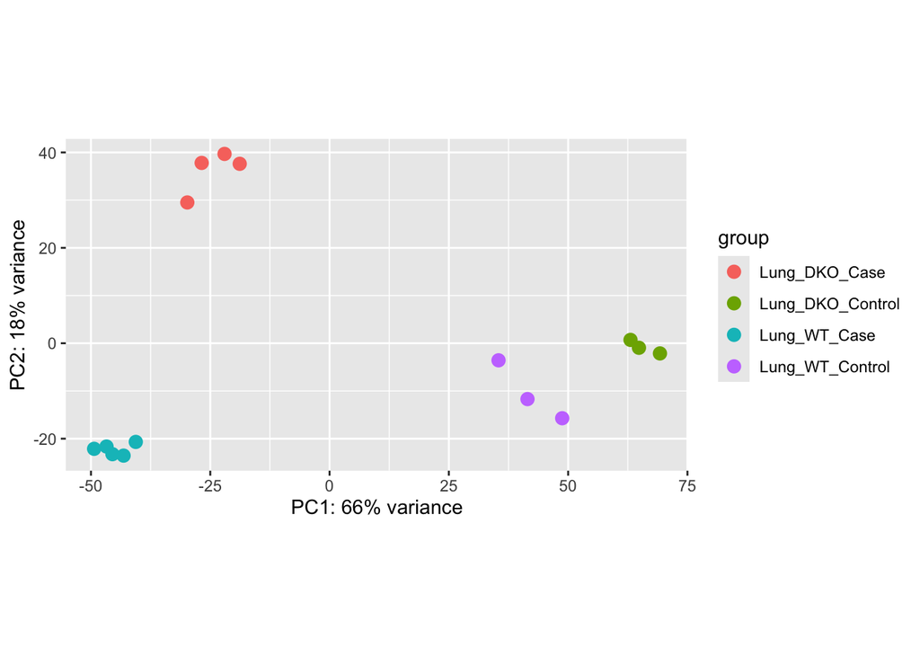

```r
DESeq2::plotPCA(vsd, intgroup = "Group")
```

DESeq2::plotPCA() does NOT return the PCA object, it only plots it. But the PCA is computed on the top variable genes of the variance-stabilized matrix (vsd), so from there we can extract the information on the top variable genes that explain most of the variation for this database (loadings).

```r
# Extract the assay matrix from VSD
mat_vsd <- SummarizedExperiment::assay(vsd)

# Select the top variable genes
library("genefilter")
rv <- rowVars(mat_vsd)    # BiocManager::install("genefilter")
select <- order(rv, decreasing = TRUE)[1:500]

# Transpose and run PCA
pca <- prcomp(t(mat_vsd[select, ]))

# Inspect the PCA results
## Variance explained by PCs
summary(pca)
```

```
## Importance of components:
##                            PC1     PC2     PC3     PC4     PC5     PC6     PC7
## Standard deviation     47.0375 24.1626 19.7662 6.82638 5.23346 4.42672 4.15426
## Proportion of Variance  0.6637  0.1752  0.1172 0.01398 0.00822 0.00588 0.00518
## Cumulative Proportion   0.6637  0.8389  0.9561 0.97009 0.97830 0.98418 0.98936
##                            PC8     PC9    PC10    PC11    PC12    PC13    PC14
## Standard deviation     3.13605 2.69889 2.16934 2.06748 1.85858 1.80724 1.62770
## Proportion of Variance 0.00295 0.00219 0.00141 0.00128 0.00104 0.00098 0.00079
## Cumulative Proportion  0.99231 0.99449 0.99591 0.99719 0.99823 0.99921 1.00000
##                             PC15
## Standard deviation     2.639e-14
## Proportion of Variance 0.000e+00
## Cumulative Proportion  1.000e+00
```

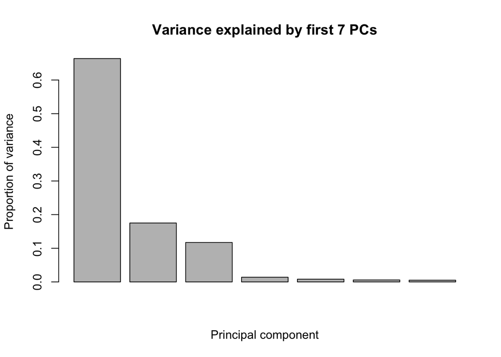

```r
# Visualize the variance explained (useful to see how many PCs matter)
barplot( (pca$sdev^2 / sum(pca$sdev^2))[1:7],
         main = "Variance explained by first 7 PCs",
         xlab = "Principal component", ylab = "Proportion of variance" )
```

```r
## Loadings (genes contributing to PCs)
loadings <- pca$rotation   # genes x PCs
head(loadings[, 1:5])      # first 5 PCs
```

```
##                           PC1         PC2        PC3        PC4         PC5
## ENSMUSG00000059668 0.13013504 -0.05081482 0.04614333 0.03711871 -0.01301046
## ENSMUSG00000055775 0.12670407 -0.04899536 0.04004559 0.04272890  0.01210015
## ENSMUSG00000044041 0.11899708 -0.03706696 0.04318305 0.03176822 -0.02043855
## ENSMUSG00000031972 0.11194207 -0.04542385 0.03907801 0.02563963  0.02971383
## ENSMUSG00000056328 0.11013247 -0.05149014 0.04407935 0.01037280  0.02280805
## ENSMUSG00000045539 0.09714832 -0.03792020 0.03662055 0.01243045 -0.03531291
```

## 6. Differential Expression analysis

```r
dss <- DESeq2::DESeq(dds)
dss
```

```
## class: DESeqDataSet
## dim: 78334 15
## metadata(1): version
## assays(4): counts mu H cooks
## rownames(78334): ENSMUSG00000104478 ENSMUSG00000104385 ...
##   ENSMUSG00002074899 ENSMUSG00002076890
## rowData names(30): baseMean baseVar ... deviance maxCooks
## colnames(15): SRR7821918 SRR7821919 ... SRR7821941 SRR7821942
## colData names(3): Sample Group sizeFactor
```

```r
DESeq2::resultsNames(dss)
```

```
## [1] "Intercept"
## [2] "Group_Lung_DKO_Control_vs_Lung_DKO_Case"
## [3] "Group_Lung_WT_Case_vs_Lung_DKO_Case"
## [4] "Group_Lung_WT_Control_vs_Lung_DKO_Case"
```

### check resultsNames and extract the comparisons of interest

To count how many are differentially expressed, check how many are not NA in the padj column and lower than the classic 0.05 threshold.

Check the number of differentially expressed genes in each comparison with *padj < 0.05*

- **WT case and DKO case**

```r
# res_WT_Case_DKO_Case <- DESeq2::results(dss, contrast = list("Group_Lung_WT_Case_vs_Lung_DKO_Case"))   SAME AS:
res_WT_Case_DKO_Case <- DESeq2::results(dss, contrast = c("Group", "Lung_WT_Case", "Lung_DKO_Case"))

WT_Case_DKO_Case <- res_WT_Case_DKO_Case[res_WT_Case_DKO_Case$padj < 0.05 & ! is.na(res_WT_Case_DKO_Case$padj), ]

sort_WT_DKO_case <- WT_Case_DKO_Case[order(WT_Case_DKO_Case$padj), ]

nrow(sort_WT_DKO_case)
```

```
## [1] 7976
```

```r
head(sort_WT_DKO_case)
```

```
## log2 fold change (MLE): Group Lung_WT_Case vs Lung_DKO_Case
## Wald test p-value: Group Lung WT Case vs Lung DKO Case
## DataFrame with 6 rows and 6 columns
##                     baseMean log2FoldChange     lfcSE      stat      pvalue
##                    <numeric>      <numeric> <numeric> <numeric>   <numeric>
## ENSMUSG00000046879  25338.59        5.65614 0.1201748   47.0659  0.0000e+00
## ENSMUSG00000078853  35167.17        6.29594 0.1395829   45.1054  0.0000e+00
## ENSMUSG00000021266  44283.88        4.12023 0.0937988   43.9262  0.0000e+00
## ENSMUSG00000037321  20945.46        4.25148 0.0985370   43.1460  0.0000e+00
## ENSMUSG00000039699   3444.21        6.57547 0.1638983   40.1192  0.0000e+00
## ENSMUSG00000033355   3286.32        5.54729 0.1446095   38.3605 6.0276e-322
##                            padj
##                       <numeric>
## ENSMUSG00000046879  0.00000e+00
## ENSMUSG00000078853  0.00000e+00
## ENSMUSG00000021266  0.00000e+00
## ENSMUSG00000037321  0.00000e+00
## ENSMUSG00000039699  0.00000e+00
## ENSMUSG00000033355 3.13626e-318
```

- **WT control vs WT case**

```r
res_WT_Control_WT_Case <- DESeq2::results(dss, contrast = c("Group", "Lung_WT_Case", "Lung_WT_Control"))

WT_Control_WT_Case <- res_WT_Control_WT_Case[res_WT_Control_WT_Case$padj < 0.05 & ! is.na(res_WT_Control_WT_Case$padj), ]

sort_WT <- WT_Control_WT_Case[order(WT_Control_WT_Case$padj), ]

nrow(sort_WT)
```

```
## [1] 11055
```

```r
head(sort_WT)
```

```
## log2 fold change (MLE): Group Lung_WT_Case vs Lung_WT_Control
## Wald test p-value: Group Lung_WT_Case vs Lung_WT_Control
## DataFrame with 6 rows and 6 columns
##                     baseMean log2FoldChange     lfcSE      stat       pvalue
##                    <numeric>      <numeric> <numeric> <numeric>    <numeric>
## ENSMUSG00000021266   44283.9        3.82463  0.101955   37.5130 5.64414e-308
## ENSMUSG00000046879   25338.6        4.28922  0.129595   33.0972 3.26015e-240
## ENSMUSG00000078853   35167.2        4.93456  0.150796   32.7234 7.25524e-235
## ENSMUSG00000024066   80970.7        3.11860  0.099873   31.2257 4.78042e-214
## ENSMUSG00000037321   20945.5        3.17540  0.106610   29.7853 6.05805e-195
## ENSMUSG00000031972   18412.8      -11.58857  0.393848  -29.4240 2.71031e-190
##                            padj
##                       <numeric>
## ENSMUSG00000021266 1.86511e-303
## ENSMUSG00000046879 5.38658e-236
## ENSMUSG00000078853 7.99165e-231
## ENSMUSG00000024066 3.94922e-210
## ENSMUSG00000037321 4.00377e-191
## ENSMUSG00000031972 1.49271e-186
```

- **WT control vs DKO control**

```r
res_WT_Control_DKO_Control <- DESeq2::results(dss, contrast = c("Group", "Lung_WT_Control", "Lung_DKO_Control"))

WT_Control_DKO_Control <- res_WT_Control_DKO_Control[res_WT_Control_DKO_Control$padj < 0.05 & ! is.na(res_WT_Control_DKO_Control$padj), ]

sort_WT_DKO_contr <- WT_Control_DKO_Control[order(WT_Control_DKO_Control$padj), ]

nrow(sort_WT_DKO_contr)
```

```
## [1] 607
```

```r
head(sort_WT_DKO_contr)
```

```
## log2 fold change (MLE): Group Lung_WT_Control vs Lung_DKO_Control
## Wald test p-value: Group Lung_WT_Control vs Lung_DKO_Control
## DataFrame with 6 rows and 6 columns
##                     baseMean log2FoldChange     lfcSE      stat      pvalue
##                    <numeric>      <numeric> <numeric> <numeric>   <numeric>
## ENSMUSG00000032690  4358.322        4.97650  0.278668   17.8582 2.49613e-71
## ENSMUSG00000033355  3286.324        2.90487  0.172096   16.8794 6.38073e-64
## ENSMUSG00000055413  2436.038        2.99131  0.177050   16.8953 4.87431e-64
## ENSMUSG00000028037  2448.212        4.91177  0.312353   15.7251 1.01865e-55
## ENSMUSG00000116656   133.603        5.89941  0.389320   15.1531 7.22572e-52
## ENSMUSG00000073409   567.564        3.59098  0.250223   14.3511 1.04794e-46
##                           padj
##                      <numeric>
## ENSMUSG00000032690 7.10872e-67
## ENSMUSG00000033355 6.05723e-60
## ENSMUSG00000055413 6.05723e-60
## ENSMUSG00000028037 7.25252e-52
## ENSMUSG00000116656 4.11563e-48
## ENSMUSG00000073409 4.97406e-43
```

- **DKO case vs DKO control**

```r
res_DKO_Control_DKO_Case <- DESeq2::results(dss, contrast = c("Group", "Lung_DKO_Control", "Lung_DKO_Case"))

DKO_Control_DKO_Case <- res_DKO_Control_DKO_Case[res_DKO_Control_DKO_Case$padj < 0.05 & ! is.na(res_DKO_Control_DKO_Case$padj), ]

sort_DKO <- DKO_Control_DKO_Case[order(DKO_Control_DKO_Case$padj), ]

dim(sort_DKO)
```

```
## [1] 11405     6
```

```r
head(sort_DKO)
```

```
## log2 fold change (MLE): Group Lung_DKO_Control vs Lung_DKO_Case
## Wald test p-value: Group Lung DKO Control vs Lung DKO Case
## DataFrame with 6 rows and 6 columns
##                     baseMean log2FoldChange     lfcSE      stat       pvalue
##                    <numeric>      <numeric> <numeric> <numeric>    <numeric>
## ENSMUSG00000031972  18412.79       12.43121  0.429144   28.9674 1.69289e-184
## ENSMUSG00000044041  27861.50       12.23570  0.478466   25.5728 3.06452e-144
## ENSMUSG00000061723   6159.24        7.16413  0.306580   23.3679 9.06155e-121
## ENSMUSG00000030672   2889.21        6.84060  0.298946   22.8824 6.95162e-116
## ENSMUSG00000030399   8591.44        8.01231  0.370826   21.6067 1.55457e-103
## ENSMUSG00000015437   7970.37       -4.80717  0.228942  -20.9973  6.94172e-98
##                            padj
##                       <numeric>
## ENSMUSG00000031972 5.59415e-180
## ENSMUSG00000044041 5.06336e-140
## ENSMUSG00000061723 9.98130e-117
## ENSMUSG00000030672 5.74291e-112
## ENSMUSG00000030399  1.02742e-99
## ENSMUSG00000015437  3.82315e-94
```

### Heatmap

Produce a heatmap to visualize the differences in the expression along all the samples.

**DKO control vs cases**

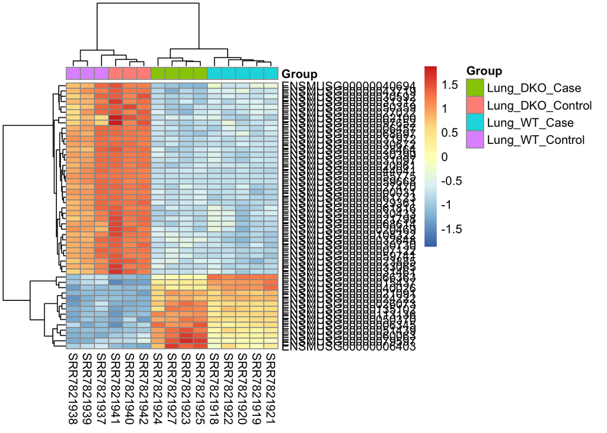

```r
# 1. Extract VSD matrix
vsd_mat <- SummarizedExperiment::assay(vsd)

# 2. Select significant genes for DKO comparison
filt_DKO <- DKO_Control_DKO_Case[(DKO_Control_DKO_Case$log2FoldChange > 3 | DKO_Control_DKO_Case$log2FoldChange < -3), ]
filt_DKO <- filt_DKO[order(filt_DKO$padj),]
filt_DKO <- filt_DKO[1:50,]
heat_DKO <- vsd_mat[rownames(filt_DKO),]


# 3. Build annotation for DKO comparison
ann <- sample_info[, "Group", drop = FALSE]
rownames(ann) <- sample_info$Sample
ann <- ann[colnames(heat_DKO), , drop = FALSE]


# 4. Plot heatmap
library(pheatmap)
  # padj filtering only
pheatmap(heat_DKO,
         annotation_col = ann,
         show_rownames = TRUE,
         fontsize_col = 10,
         clustering_distance_rows = "euclidean",
         clustering_distance_cols = "euclidean",
         clustering_method = "complete",
         scale = "row")
```

Repeat steps from 2 to 4 for all the other comparisons

**WT vs DKO control**

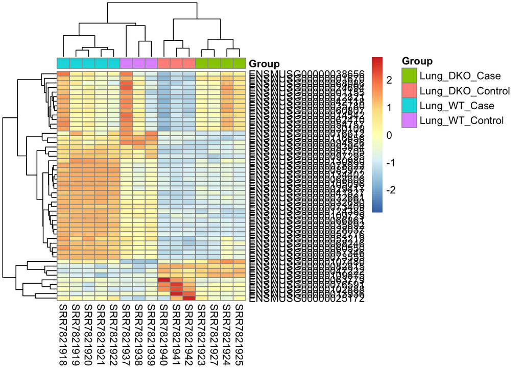

```r
# 2. Select significant genes for DKO comparison
filt_Control <- WT_Control_DKO_Control[(WT_Control_DKO_Control$log2FoldChange > 3 | WT_Control_DKO_Control$log2FoldChange < -3), ]
filt_Control <- filt_Control[order(filt_Control$padj),]
filt_Control <- filt_Control[1:50,]
heat <- vsd_mat[rownames(filt_Control),]


# 3. Build annotation for DKO comparison
ann <- ann[colnames(heat_DKO), , drop = FALSE]


# 4. Plot heatmap
library(pheatmap)
  # padj filtering only
pheatmap(heat,
         annotation_col = ann,
         show_rownames = TRUE,
         fontsize_col = 10,
         clustering_distance_rows = "euclidean",
         clustering_distance_cols = "euclidean",
         clustering_method = "complete",
         scale = "row")
```

**WT control vs case**

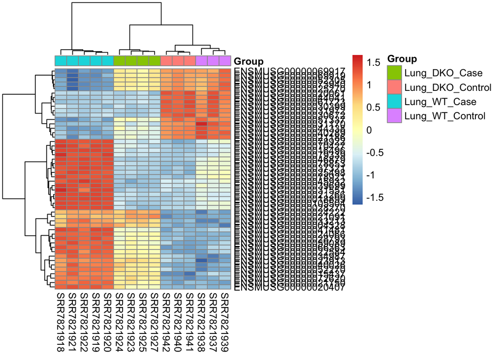

```r
# 2. Select significant genes for DKO comparison
filt_WT <- WT_Control_WT_Case[(WT_Control_WT_Case$log2FoldChange > 3 | WT_Control_WT_Case$log2FoldChange < -3), ]
filt_WT <- filt_WT[order(filt_WT$padj),]
filt_WT <- filt_WT[1:50,]
heat <- vsd_mat[rownames(filt_WT),]


# 3. Build annotation for DKO comparison
ann <- ann[colnames(heat_DKO), , drop = FALSE]


# 4. Plot heatmap
library(pheatmap)
  # padj filtering only
pheatmap(heat,
         annotation_col = ann,
         show_rownames = TRUE,
         fontsize_col = 10,
         clustering_distance_rows = "euclidean",
         clustering_distance_cols = "euclidean",
         clustering_method = "complete",
         scale = "row")
```

**WT vs DKO case**

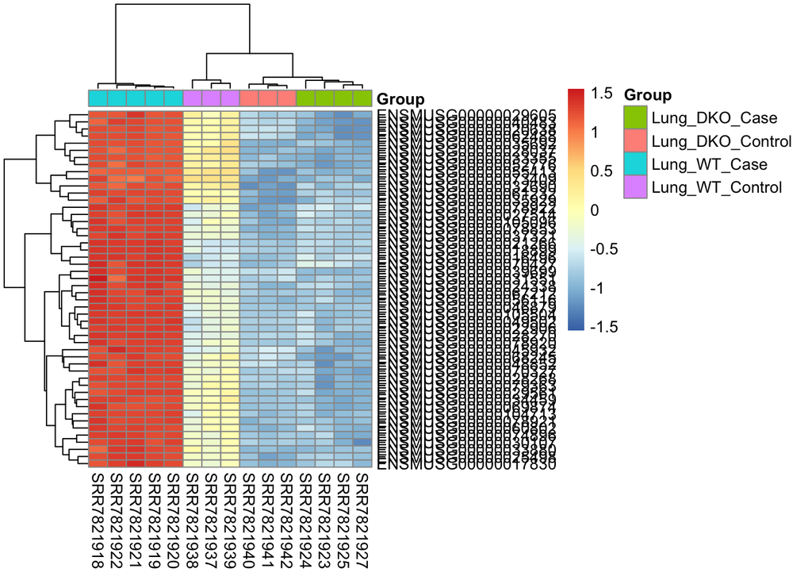

```r
# 2. Select significant genes for DKO comparison
filt_Case <- WT_Case_DKO_Case[(WT_Case_DKO_Case$log2FoldChange > 3 | WT_Case_DKO_Case$log2FoldChange < -3), ]
filt_Case <- filt_Case[order(filt_Case$padj),]
filt_Case <- filt_Case[1:50,]
heat <- vsd_mat[rownames(filt_Case),]


# 3. Build annotation for DKO comparison
ann <- ann[colnames(heat_DKO), , drop = FALSE]


# 4. Plot heatmap
library(pheatmap)
  # padj filtering only
pheatmap(heat,
         annotation_col = ann,
         show_rownames = TRUE,
         fontsize_col = 10,
         clustering_distance_rows = "euclidean",
         clustering_distance_cols = "euclidean",
         clustering_method = "complete",
         scale = "row")
```

### Volcano plot

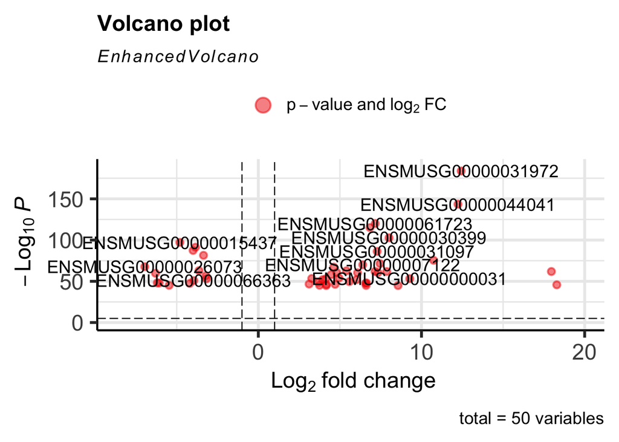

```r
# install.packages("devtools")
# devtools::install_github("kevinblighe/EnhancedVolcano")
library("EnhancedVolcano")
library("ggrepel")

EnhancedVolcano(filt_DKO,
    lab = rownames(filt_DKO),
    x = 'log2FoldChange',
    y = 'pvalue')
```

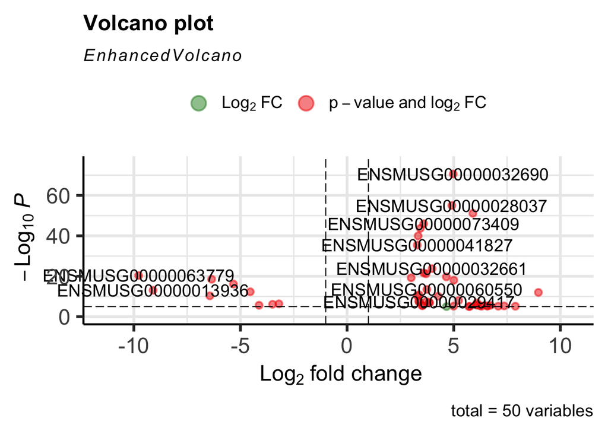

```r
EnhancedVolcano(filt_Control,
    lab = rownames(filt_Control),
    x = 'log2FoldChange',
    y = 'pvalue')
```

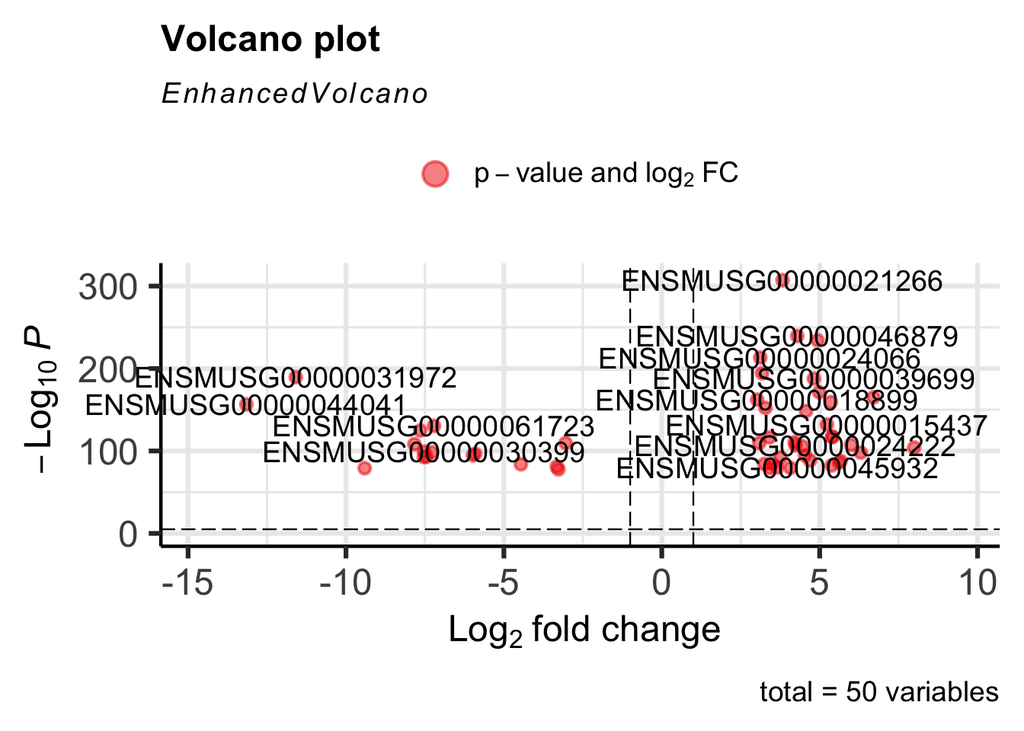

```r
EnhancedVolcano(filt_WT,
    lab = rownames(filt_WT),
    x = 'log2FoldChange',
    y = 'pvalue')
```

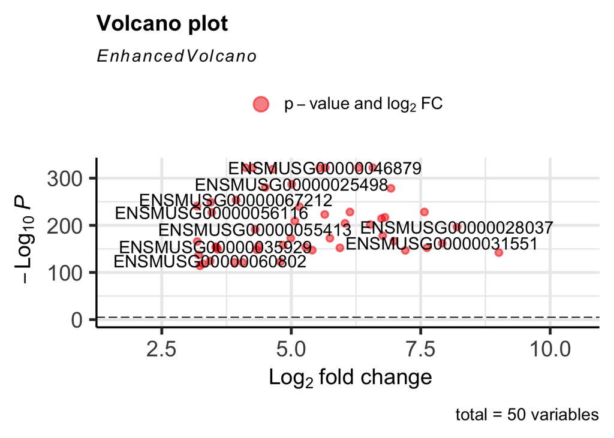

```r
EnhancedVolcano(filt_Case,
    lab = rownames(filt_Case),
    x = 'log2FoldChange',
    y = 'pvalue')
```

**MAKE THE FOLLOWING A TABLE IN THE REPORT**

How many genes are differentially expressed (DE) in the pairwise comparison you selected (e.g. padj < 0.05)?

```r
paste0("There has been found ", nrow(DKO_Control_DKO_Case), " DE genes in DKO control vs case comparison having padj < 0.05.")
```

```
## [1] "There has been found 11405 DE genes in DKO control vs case comparison having padj < 0.05."
```

```r
paste0("There has been found ", nrow(WT_Control_DKO_Control), " DE genes in WT vs DKO control comparison having padj < 0.05.")
```

```
## [1] "There has been found 607 DE genes in WT vs DKO control comparison having padj < 0.05."
```

```r
paste0("There has been found ", nrow(WT_Control_WT_Case), " DE genes in WT control vs case comparison having padj < 0.05.")
```

```
## [1] "There has been found 11055 DE genes in WT control vs case comparison having padj < 0.05."
```

```r
paste0("There has been found ", nrow(WT_Case_DKO_Case), " DE genes in WT vs DKO case comparison having padj < 0.05.")
```

```
## [1] "There has been found 7976 DE genes in WT vs DKO case comparison having padj < 0.05."
```

How many of the DE genes are up-regulated vs down-regulated meaningfully (padj < 0.05)?

```r
paste0("For DKO control vs case are ", sum(DKO_Control_DKO_Case$log2FoldChange > 0), " upregulated and ", length(DKO_Control_DKO_Case$log2FoldChange) - sum(DKO_Control_DKO_Case$log2FoldChange > 0), " downregulated.")
```

```
## [1] "For DKO control vs case are 5929 upregulated and 5476 downregulated."
```

```r
paste0("For WT vs DKO control are ", sum(WT_Control_DKO_Control$log2FoldChange > 0), " upregulated and ", length(WT_Control_DKO_Control$log2FoldChange) - sum(WT_Control_DKO_Control$log2FoldChange > 0), " downregulated.")
```

```
## [1] "For WT vs DKO control are 397 upregulated and 210 downregulated."
```

```r
paste0("For WT controls vs cases are ", sum(WT_Control_WT_Case$log2FoldChange > 0), " upregulated and ", length(WT_Control_WT_Case$log2FoldChange) - sum(WT_Control_WT_Case$log2FoldChange > 0), " downregulated.")
```

```
## [1] "For WT controls vs cases are 5090 upregulated and 5965 downregulated."
```

```r
paste0("For WT vs DKO case are ", sum(WT_Case_DKO_Case$log2FoldChange > 0), " upregulated and ", length(WT_Case_DKO_Case$log2FoldChange) - sum(WT_Case_DKO_Case$log2FoldChange > 0), " downregulated.")
```

```
## [1] "For WT vs DKO case are 3671 upregulated and 4305 downregulated."
```

Based on the original publication, select 2-3 genes that are of particular interest and investigate their expression level. You could use, for example, the normalized counts (see DESeq2::counts) where the effect of between-sample differences in sequencing depth has been removed.

Use the box plot to visualize fold change and significance (adj p-value) for the few selected genes for my report.

How to find genes:

- read paper (see ToDo.md)
- find ensemble code
- look for the gene in the comparison of interest and extract info
- box plot with the info

### genes from paper

Install database

```r
if (!require("org.Mm.eg.db", quietly = TRUE))
  BiocManager::install("org.Mm.eg.db")

library(org.Mm.eg.db)
library(AnnotationDbi)
```

**Control vs Cases**

```r
gfilter <- function(symbols, dss){
  ens_ids <- mapIds(
    org.Mm.eg.db,
    keys      = symbols,
    column    = "ENSEMBL",
    keytype   = "SYMBOL",
    multiVals = "first"
  )

  dss_fil <- dss[grepl(paste(unname(ens_ids), collapse="|"), row.names(dss), ignore.case = TRUE), ]

  # add gene name to the data frame
  gene_map_one <- data.frame(
    ENSEMBL = unname(ens_ids),
    name    = names(ens_ids),
    stringsAsFactors = FALSE
  )

  dss_fil$name <- gene_map_one$name[match(rownames(dss_fil), gene_map_one$ENSEMBL)]

  return(dss_fil)
}

# list of gene names to convert into ENSEMBLE codes
## L5 (type I IFN)
symbols <- c(
  "Ifnb1", "Ifit1", "Ifit3", "Oas1a", "Oas2", "Oas3", "Oasl1", "Oasl2", "Mx1", "Stat2", "Irf7", "Irf9"
)

DKO_typeI <- gfilter(symbols, DKO_Control_DKO_Case)
WT_typeI <- gfilter(symbols, WT_Control_WT_Case)
Case_typeI <- gfilter(symbols, WT_Case_DKO_Case)
## L7 (type II IFN)
symbols <- c(
  "Ifng", "Irf1", "Irf2", "Irf8", "Il12rb1", "Il12rb2", "Tap1", "Tap2", "Gbp2", "Gbp3", "Gbp4", "Gbp5", "Gbp6", "Gbp8", "Gbp9", "Gbp10", "Gbp11"
)


DKO_typeII <- gfilter(symbols, DKO_Control_DKO_Case)
WT_typeII <- gfilter(symbols, WT_Control_WT_Case)
Case_typeII <- gfilter(symbols, WT_Case_DKO_Case)
```

## 7. Overrepresentation analysis

**Hypergeometric test** to check overrepresentation

The databases for overrepresentation test where you can get the pathway categorization are: - GO - KEGG - Reactome - Wikipaths

I would use GO and KEGG (more curated? justify the choice)

Install clusterProfiler

```r
if (!require("BiocManager", quietly = TRUE))
  install.packages("BiocManager")

if (!require("clusterProfiler", quietly = TRUE))
  BiocManager::install("clusterProfiler")
# the link to enrichplot is broken in bioconductor, install directly
if (!require("enrichplot", quietly = TRUE))
  BiocManager::install("enrichplot", force = TRUE)
# without updating the other packages (might create problems with dependencies)

library("clusterProfiler")
```

Download Bioconductor package with genome wide annotation for your species

```r
if (!require("org.Mm.eg.db", quietly = TRUE))
  BiocManager::install("org.Mm.eg.db")
```

Call enrichGO

```r
# Select significant genes WT control and cases and run the enrichment via Gene Ontology
ego_WT <- clusterProfiler::enrichGO(
  gene = rownames(WT_Control_WT_Case),
  universe = rownames(dss),
  OrgDb = org.Mm.eg.db,
  ont = "BP",
  keyType = "ENSEMBL",
  maxGSSize = 150,
  pvalueCutoff = 0.05
  )

ego_DKO <- clusterProfiler::enrichGO(
  gene = rownames(DKO_Control_DKO_Case),
  universe = rownames(dss),
  OrgDb = org.Mm.eg.db,
  ont = "BP",
  keyType = "ENSEMBL",
  maxGSSize = 150,
  pvalueCutoff = 0.05
  )

ego_Case <- clusterProfiler::enrichGO(
  gene = rownames(WT_Case_DKO_Case),
  universe = rownames(dss),
  OrgDb = org.Mm.eg.db,
  ont = "BP",
  keyType = "ENSEMBL",
  maxGSSize = 150,
  pvalueCutoff = 0.05
  )
```

- *gene = rownames()*

  should be a vector of ENSEMBL gene IDs that are significantly DE.
- *universe = rownames(mat)*

  All genes measured in the experiment. Since mat is your DESeq2 input matrix, its row names are all ENSEMBL IDs → perfect universe.
- *OrgDb = org.Mm.eg.db*

  Genome-wide mouse annotation package from Bioconductor.
- *ont = “BP”* or “MF”, “CC”, or “ALL”

  GO subontology:
  - BP: Biological Process
  - MF: Molecular Function
  - CC: Cellular Component
- *keyType = “ENSEMBL”*

  Because your gene IDs (row names) are ENSEMBL IDs like “ENSMUSG00000000001”.
- *maxGSSize = 150* maximal size of genes annotated for testing

Work on the results of enrichGO

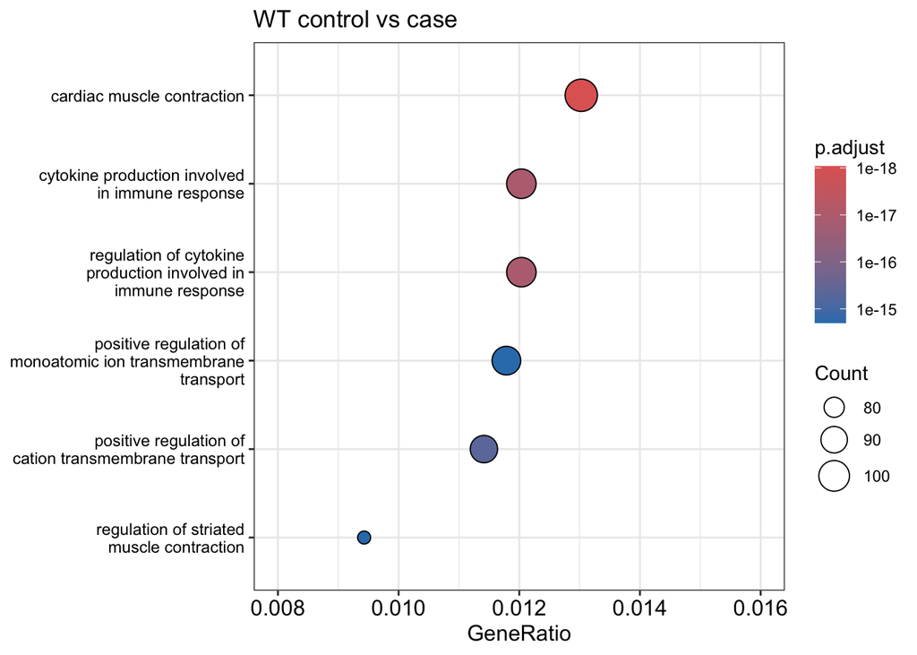

```r
library(ggplot2)

dotplot(ego_WT, showCategory = 6, title = "WT control vs case") + theme(axis.text.y = element_text(size = 9)) + coord_cartesian(xlim = c(0.008, 0.016))
```

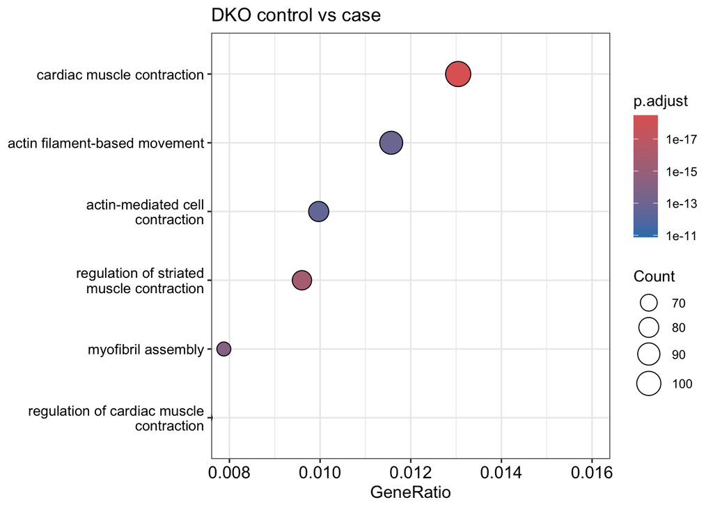

```r
dotplot(ego_DKO, showCategory = 6, title="DKO control vs case") + theme(axis.text.y = element_text(size = 10)) + coord_cartesian(xlim = c(0.008, 0.016))
```

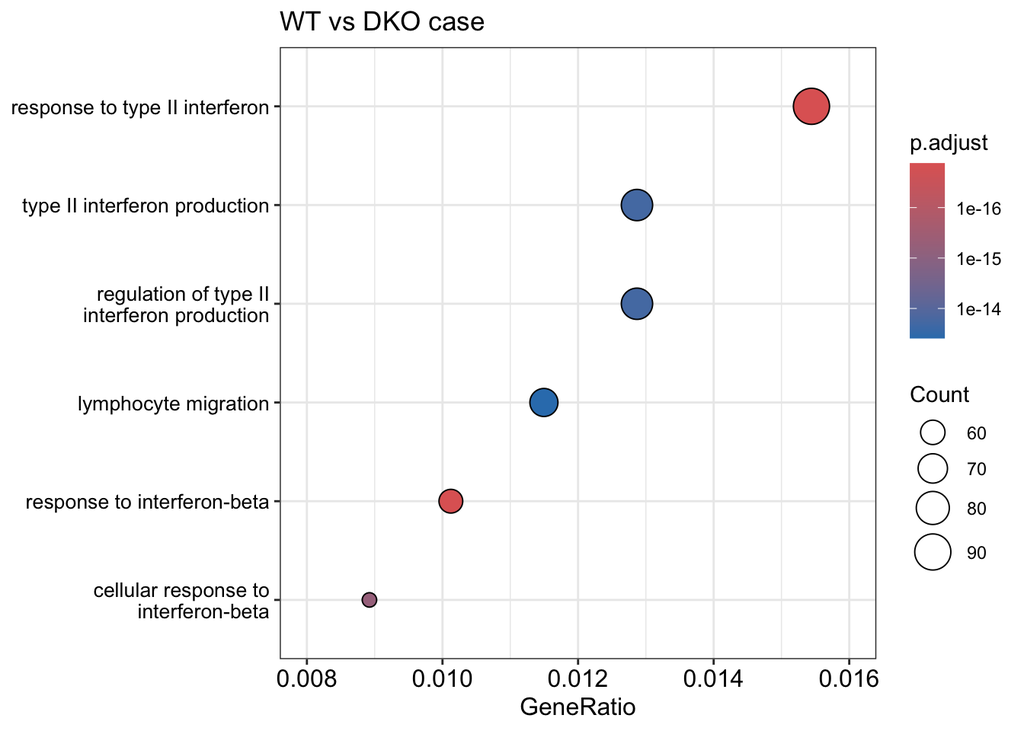

```r
dotplot(ego_Case, showCategory = 6, title="WT vs DKO case") + theme(axis.text.y = element_text(size = 10)) + coord_cartesian(xlim = c(0.008, 0.016))
```

## Check if BP from overrepresentation analysis make sense

I want to use the genes that I know to be part of the biological processes (from the paper) and look for their BP. Once I have the BP I can compare them with the results of the analysis to see if they are present or not.

1. Retrieve GO BP annotations for known genes belonging to type I and type II IFN

```r
# function to retrieve the GO BP annotations
get_BP <- function(genes){
  go <- AnnotationDbi::select(
    org.Mm.eg.db,
    keys = genes,
    keytype = "ENSEMBL",
    columns = c("GO", "ONTOLOGY")
  )

  go_bp <- go[go$ONTOLOGY == "BP", ] # filter for BP term only

  library(GO.db)
  go_bp$Description <- Term(go_bp$GO) # get the description referring to the GO code
  uniq <- unique(go_bp$Description) # choose only the unique ones
  uniq <- uniq[!is.na(uniq)] # drop na

  return(uniq)
}

BP_one <- get_BP(rownames(Case_typeI)) # use the ENSEMBL code of the genes
BP_two <- get_BP(rownames(Case_typeII))
```

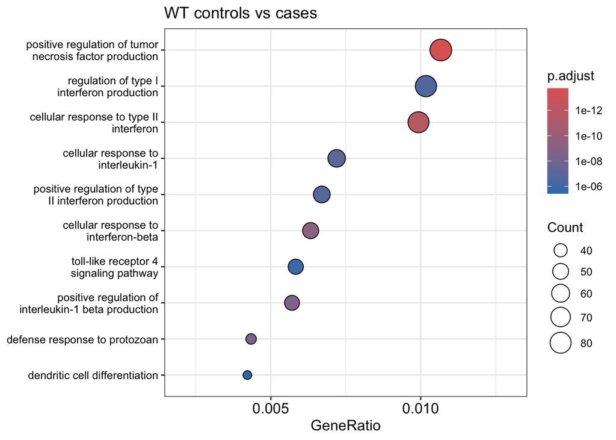

```r
keywords <- append(BP_one, BP_two)

ego_plot <- function(ego, keywords, name){
  ego_fil <- ego

  # filter for keywords of type I and type II TFN present in the enrichment of the comparison chosen
  ego_fil@result <- ego@result[ego@result$Description %in% keywords, ]

  dotplot(ego_fil, showCategory = 10, title = name) + theme(axis.text.y = element_text(size = 9)) + coord_cartesian(xlim = c(0.002, 0.013))
}

ego_plot(ego_WT, keywords, "WT controls vs cases")
```

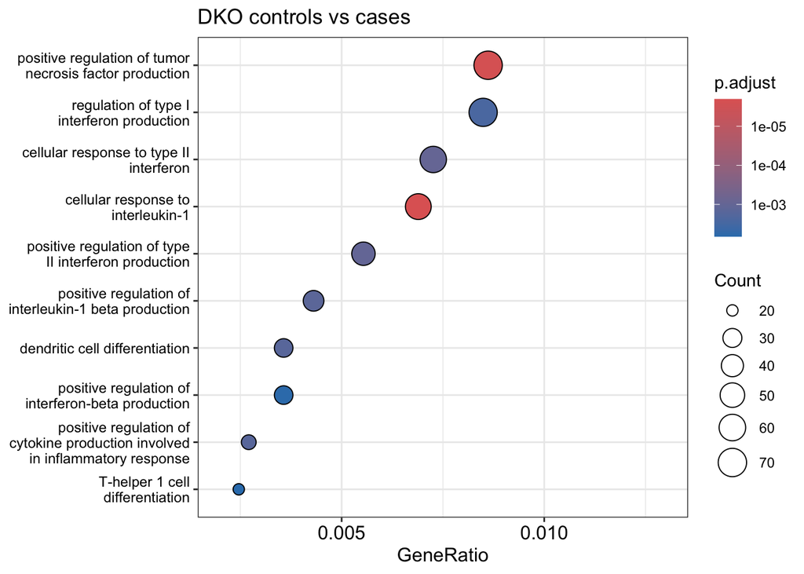

```r
ego_plot(ego_DKO, keywords, "DKO controls vs cases")
```

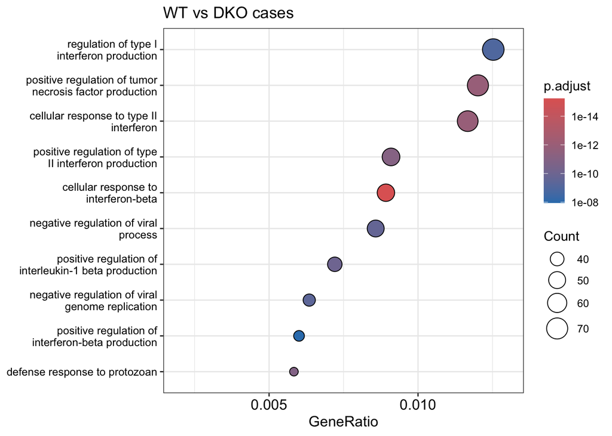

```r
ego_plot(ego_Case, keywords, "WT vs DKO cases")
```